# Monte Carlo

Yifei Liu

2/19/2019

```r
library(forcats)
library(tidyverse)
library(scales)
library(ggfortify)
detach("package:dplyr", unload=TRUE)
library(dplyr)
theme_set(theme_minimal())
```

Estimating $\pi$

```r
estimate_pi <- function(n) {
  count = 0
  for (i in 1:n) {
    x = runif(1)
    y = runif(1)
    if ((x - 0.5) ^ 2 + (y - 0.5) ^ 2 <= 0.5^2)
      count = count + 1
  }
  PI = 4 * count / n
  print(PI)
}

estimate_pi(10000)
```

```
## [1] 3.1352
```

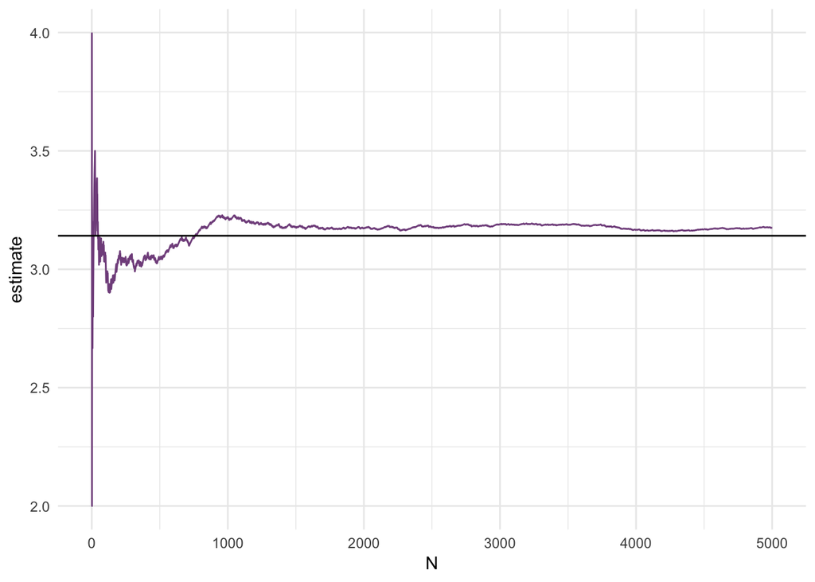

```r
n <- 5000


points <- tibble("x" = runif(n), "y" = runif(n))


points <- points %>%
  mutate(inside = if_else(x^2 + y^2 < 1, 1, 0),
         N = row_number(),
         estimate = 4*cumsum(inside)/N)

ggplot(points) +
  geom_line(aes(y = estimate, x = N), colour = "#82518c") +
  geom_hline(yintercept = pi)
```

Discretized Stock Prcoess

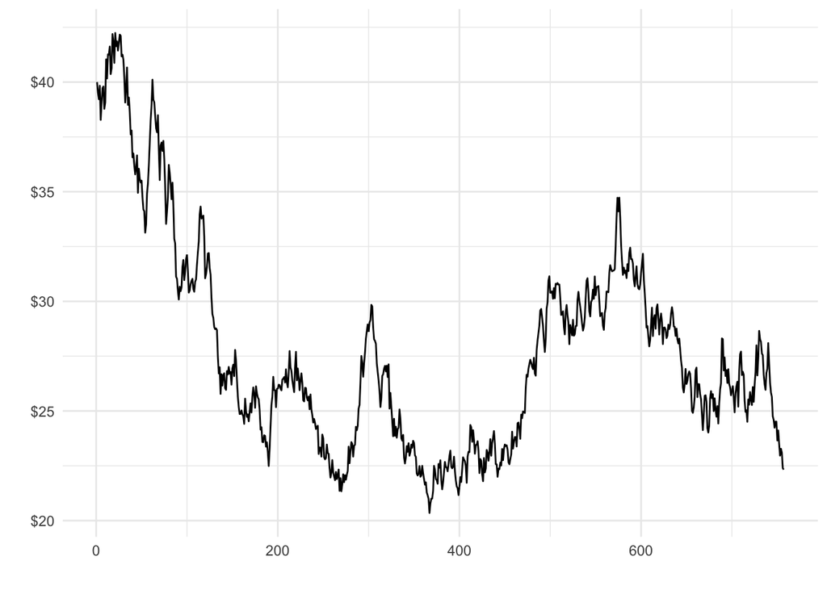

```r
geo_paths <- function(s, r, q, sd, t, n) {
  paths = NULL
  paths[1] = s
  dt = t/n
  drift = (r - sd^2 /2) * dt
  risk = sd * sqrt(dt)
  for (i in 1:n) {
    paths[i + 1] = paths[i] * exp(drift + risk * rnorm(1))
  }
  paths <- as.ts(paths)
  return(paths)
}

geo_price <- geo_paths(40, 0.05, 0.03, 0.35, 3, 3*252)

autoplot(geo_price) +
  scale_y_continuous(labels = dollar_format())
```

BS European Call

```r
BSCallMC <- function(s, k, r, q, t, sd, nr) {
  drift = (r - q - sd^2/2) * t
  risk = sd * sqrt(t)
  st <- NULL
  intrinsic <- NULL
  prices <- NULL
  for(i in 1:nr) {
    st[i] = s * exp(drift + risk * rnorm(1))
    intrinsic[i] = max(0, st[i] - k)
    prices[i] <- exp(-r*t) * intrinsic[i]
  }

  return(mean(prices))
}

BSCallMC(20, 20, 0.03, 0, 5/12, 0.25, 10000)
```

```
## [1] 1.37076
```

# Extra

1. RANDU is an infamus linear congruential pseudorandom number generator which has been used since the 1960s in what way could it be judged faulty

2. What is mean by the Quasi Monte Carlo?

Anser: it been generated deterministely way, have systemically bias, not real random number.

3. Quasi Random Sequence using a base 2 manipualtion

Answer:

1 = 1.0 = 0.1 = 1/2 2 - 11.0 = 0.01 = 1/4 3 = 11.0 = 0.11 = 3/4 4 = 100,0 = 0.001 = 1/8 5 = 101.0 = 0.101 = 5/8

m equalt the number of jumps in interval of times

$z_i $ stand normal variable $N(0,1)$ percentage of change

$v_j$ expected size of jump p

$\sigma_i$ volatility in the jump size

$$Y = e^{m*(\alpha_j - 0.5\sigma_j^2) + \sigma_j * \sum_{1}^{m}{z}}$$

5 A:

How could the merton jump diffusion model explain observed equility volatltiy smiles?

1. Collect data cp for range

why we observe volatility smiles Answer: Returns not lognormal, heavy right tails

2. regressional equation

$\sigma_{iv} = q_o + q_1k + q_2k + q_3T + q_sKT$

$dx = udt + \sigma{dw_t}$ = drift + diffusion coefficient

Constant Elasticity of Variance - CEV

$ds/s = (r-q)dt + \sigma{dw}$

If we want stock to have volatility of $\sigma_0$ at Current S: $\sigma = \sigma_0 S^{(2-\beta)/2}$

$\beta < 2$ Volatility decrease with Stock Price

Volatility in this case is either fixed or random.

2. Show that it exhibits constant elasticity of variance?

$\sigma^2 = \sigma_0^2{S\beta}$

Discrete method of CEV

$ds = (r-q)sdt + \sigma{s^{\beta/2}}dw$ $d*lns = 1/s *ds + 1/2 * (-1/s^2)(ds)^2$ $s_{\delta_t} = s_0 * exp\{(r-q) - 1/2 *\sigma^2*s^{\beta-2} + \sigma*s^{\beta-2}\}$

CEVpath

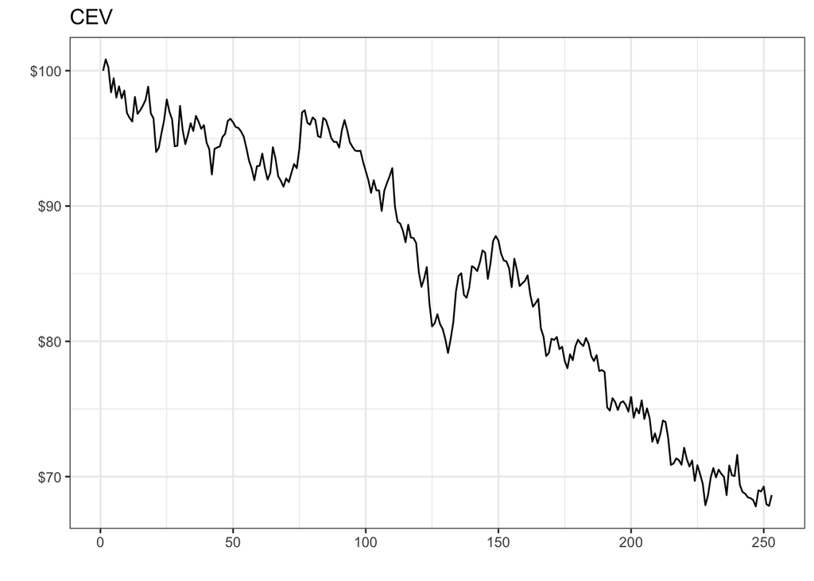

```r
CEVPath <- function(s,r,q,vol0, beta, t, n) {
  set.seed(2019)
  path <- NULL
  path[1] <- s
  sigma = vol0*s^((2-beta)/2)
  dt = t/n
  sqrtdt = sqrt(dt)
  var = sigma^2
  for (i in 1:n) {
    drift = (r - q - 0.5 * var * path[i]^(beta-2)) * dt
    risk = sigma * (path[i]^((beta-2)/2)*sqrtdt)
    path[i+1] = path[i] * exp(drift + risk * rnorm(1))
  }
  path_ts = as.ts(path)
  return(path_ts)

}


price_ts <- CEVPath(100, 0.026, 0.015, 0.18, 1, 1, 252)

 autoplot(price_ts) +
    theme_bw() +
    scale_y_continuous(labels = dollar_format()) +
    labs(x= "", y = "", title = "CEV")
```

Volpath